# Primer 369

Markus Min

11/5/2018

## Primer 369

##### Forward: AAGCTCATTCAAGTGCTT

##### Reverse: GACCACTTACACAATTCT

##### Forward primer Tm: 52.7 C

##### Reverse primer Tm: 49.9 C

##### Forward GC Content: 39% (7/18 bases)

##### Reverse GC Content: 39% (7/18 bases)

##### Amplicon length: 153 BP

Notes: This primer was created using ecoPrimers, a program used to design primers that amplify a certain group of target taxa and avoid a group of untarget taxa. The input sequences that were used in ecoPrimers were generated by amplifying vertebrate sequences using a primer from a previous study that was used to amplify the Sebastes cytB gene. The target group was the genus Sebastes, and the untarget group was the order Perciformes.

### Importing Data

```r
library(ROBIUtils)
library(ROBITaxonomy)
library(ROBIBarcodes)
library(ROBITools)
setwd("//Users/Markus/Documents/UCLA/Barber Lab/Honor's Thesis/ecoPCR_results")
fish = read.ecopcr.result("primer369_11.5.18.ecoPCR")
setwd("//Users/Markus/Documents/UCLA/Barber Lab/Honor's Thesis/R_Files/ncbidb")
taxo = read.taxonomy("ncbidatabase")
teleo.taxid = ecofind(taxo, '^Teleostei$')
is_a_fish=is.subcladeof(taxo,fish$taxid,teleo.taxid)
sebastes.taxid = ecofind(taxo, '^Sebastes$')
is_a_rockfish=is.subcladeof(taxo,fish$taxid,sebastes.taxid)
table(is_a_fish)
```

```
## is_a_fish
## FALSE  TRUE
##     1  1938
```

```r
# 1938 fish sequences amplified, 1 non-fish vertebrates
```

Notes: The object “fish” is created by reading the file “primer369_11.5.18.ecoPCR,” which contains the amplified sequences from using Primer 369 in an in silico PCR through the program “ecoPCR.”

### Testing the Conservation of the Priming Sites

```r
#'@include ROBIBarcodes.R
NULL
```

```r
svg.A.path="m 53.417969,-13.28125 -29.394532,0 L 19.384766,0 0.48828125,0 27.490234,-72.900391 l 22.41211,0 L 76.904297,0 58.007812,0 53.417969,-13.28125 m -24.707032,-13.525391 19.970704,0 -9.960938,-29.003906 -10.009766,29.003906"
svg.C.path="M 66.992187,-4.0039062 C 63.541603,-2.2135395 59.944602,-0.86262935 56.201172,0.04882812 52.45763,0.9602855 48.551384,1.4160142 44.482422,1.4160156 32.340462,1.4160142 22.721331,-1.9693991 15.625,-8.7402344 8.5286373,-15.543604 4.9804638,-24.755835 4.9804687,-36.376953 4.9804638,-48.030551 8.5286373,-57.242781 15.625,-64.013672 c 7.096331,-6.803314 16.715462,-10.205004 28.857422,-10.205078 4.068962,7.4e-5 7.975208,0.455803 11.71875,1.367188 3.74343,0.91153 7.340431,2.26244 10.791015,4.052734 l 0,15.087891 c -3.483136,-2.376246 -6.917377,-4.117781 -10.302734,-5.22461 -3.38547,-1.106711 -6.949919,-1.660096 -10.693359,-1.660156 -6.705769,6e-5 -11.979201,2.148496 -15.820313,6.445312 -3.841172,4.296925 -5.761743,10.221398 -5.761719,17.773438 -2.4e-5,7.51956 1.920547,13.427757 5.761719,17.724609 3.841112,4.29689 9.114544,6.445325 15.820313,6.445313 3.74344,1.2e-5 7.307889,-0.553373 10.693359,-1.660157 3.385357,-1.106755 6.819598,-2.84829 10.302734,-5.224609 l 0,15.0878908"
svg.G.path="m 74.707031,-5.4199219 c -4.68757,2.278649 -9.554101,3.9876317 -14.599609,5.12695315 C 55.061794,0.84635332 49.853466,1.4160142 44.482422,1.4160156 32.340462,1.4160142 22.721331,-1.9693991 15.625,-8.7402344 8.5286373,-15.543604 4.9804638,-24.755835 4.9804687,-36.376953 c -4.9e-6,-11.751254 3.6132727,-20.996037 10.8398443,-27.734375 7.226539,-6.738211 17.122362,-10.107348 29.687499,-10.107422 4.850211,7.4e-5 9.488878,0.455803 13.916016,1.367188 4.459572,0.91153 8.658786,2.26244 12.597656,4.052734 l 0,15.087891 c -4.069078,-2.311142 -8.121808,-4.036401 -12.158203,-5.175782 -4.003962,-1.139263 -8.02414,-1.708924 -12.060547,-1.708984 -7.487019,6e-5 -13.265008,2.099668 -17.333984,6.298828 -4.036485,4.166717 -6.054712,10.140018 -6.054688,17.919922 -2.4e-5,7.714872 1.953099,13.671898 5.859375,17.871094 3.906216,4.199233 9.456341,6.29884 16.650391,6.298828 1.953076,1.2e-5 3.759715,-0.11392 5.419922,-0.341797 1.692654,-0.260404 3.206325,-0.651029 4.541016,-1.171875 l 0,-14.160156 -11.47461,0 0,-12.597657 29.296875,0 0,35.0585941"
svg.T.path="m 0.48828125,-72.900391 l 67.18749975,0 0,14.208985 -24.169922,0 0,58.691406 -18.798828,0 0,-58.691406 -24.21874975,0 0,-14.208985"
svg.R.path="m 35.888672,-40.576172 c 3.938762,4.1e-5 6.754515,-0.73238 8.447265,-2.197265 1.725215,-1.4648 2.587844,-3.873652 2.587891,-7.226563 -4.7e-5,-3.320259 -0.862676,-5.696559 -2.587891,-7.128906 -1.69275,-1.432233 -4.508503,-2.148378 -8.447265,-2.148438 l -7.910156,0 0,18.701172 7.910156,0 m -7.910156,12.988281 0,27.587891 -18.7988285,0 0,-72.900391 28.7109375,0 c 9.602817,7.3e-5 16.63406,1.6114 21.09375,4.833985 4.492124,3.222721 6.738216,8.317117 6.738281,15.283203 -6.5e-5,4.817756 -1.171939,8.77283 -3.515625,11.865234 -2.311258,3.092486 -5.810603,5.37113 -10.498047,6.835938 2.571561,0.585971 4.86648,1.920605 6.884766,4.003906 2.050721,2.050809 4.117776,5.175806 6.201172,9.375 L 75,0 54.980469,0 46.09375,-18.115234 c -1.790409,-3.645812 -3.613324,-6.136044 -5.46875,-7.470703 -1.822955,-1.334609 -4.264359,-2.001926 -7.324219,-2.001954 l -5.322265,0"
svg.Y.path="m -0.9765625,-72.900391 20.5566405,0 16.601563,25.976563 16.601562,-25.976563 20.605469,0 -27.783203,42.1875 0,30.712891 -18.798828,0 0,-30.712891 -27.7832035,-42.1875"
svg.M.path="m 9.1796875,-72.900391 23.9257815,0 16.601562,39.013672 16.699219,-39.013672 23.876953,0 0,72.900391 -17.773437,0 0,-53.320312 -16.796875,39.30664 -11.914063,0 -16.796875,-39.30664 0,53.320312 -17.8222655,0 0,-72.900391"
svg.K.path="m 9.1796875,-72.900391 18.7988285,0 0,26.611329 27.099609,-26.611329 21.826172,0 L 41.796875,-38.378906 80.517578,0 56.982422,0 27.978516,-28.710937 27.978516,0 9.1796875,0 l 0,-72.900391"
svg.W.path="m 2.9785156,-72.900391 18.0175784,0 12.597656,52.978516 12.5,-52.978516 18.115234,0 12.5,52.978516 12.597657,-52.978516 17.871089,0 L 89.990234,0 68.310547,0 55.078125,-55.419922 41.992187,0 20.3125,0 2.9785156,-72.900391"
svg.S.path="m 59.912109,-70.605469 0,15.429688 c -4.003962,-1.790308 -7.910208,-3.141218 -11.71875,-4.052735 -3.808638,-0.911398 -7.405639,-1.367127 -10.791015,-1.367187 -4.492221,6e-5 -7.81253,0.618549 -9.960938,1.855469 -2.148463,1.237036 -3.22268,3.157607 -3.222656,5.761718 -2.4e-5,1.953176 0.716121,3.483123 2.148437,4.589844 1.464816,1.074266 4.101533,2.002 7.910157,2.783203 l 8.007812,1.611328 c 8.105419,1.627647 13.867132,4.101603 17.285156,7.421875 3.417906,3.320346 5.126889,8.040393 5.126954,14.160157 -6.5e-5,8.040379 -2.392641,14.0299559 -7.177735,17.9687496 -4.752657,3.90625056 -12.02804,5.8593736 -21.826172,5.859375 C 31.070932,1.4160142 26.432265,0.97656152 21.777344,0.09765625 17.122379,-0.78124922 12.467435,-2.0833313 7.8125,-3.8085938 l 0,-15.8691402 c 4.654935,2.473975 9.147118,4.345718 13.476562,5.615234 4.361954,1.236992 8.561169,1.855481 12.597657,1.855469 4.101524,1.2e-5 7.242797,-0.683581 9.423828,-2.050782 2.180944,-1.367171 3.271438,-3.320294 3.271484,-5.859374 -4.6e-5,-2.278624 -0.748744,-4.036435 -2.246094,-5.273438 -1.464886,-1.236953 -4.410847,-2.343722 -8.83789,-3.320312 l -7.275391,-1.611329 c -7.291687,-1.562468 -12.630224,-4.0527 -16.015625,-7.470703 -3.3528732,-3.417927 -5.0293038,-8.024042 -5.0292966,-13.818359 -7.2e-6,-7.259056 2.3437405,-12.841733 7.0312496,-16.748047 4.687481,-3.906178 11.425756,-5.859301 20.214844,-5.859375 4.003868,7.4e-5 8.121702,0.309319 12.353516,0.927734 4.23172,0.586011 8.60997,1.481192 13.134765,2.685547"
svg.B.path="m 38.378906,-44.677734 c 2.962198,4.4e-5 5.20829,-0.650997 6.738281,-1.953125 1.529902,-1.302036 2.294875,-3.222607 2.294922,-5.761719 -4.7e-5,-2.506456 -0.76502,-4.410751 -2.294922,-5.712891 -1.529991,-1.334576 -3.776083,-2.001893 -6.738281,-2.001953 l -10.40039,0 0,15.429688 10.40039,0 m 0.634766,31.884765 c 3.775999,1.3e-5 6.608027,-0.797512 8.496094,-2.392578 1.920523,-1.595035 2.880809,-4.003887 2.880859,-7.226562 -5e-5,-3.157527 -0.94406,-5.517551 -2.832031,-7.080078 -1.888067,-1.595021 -4.736371,-2.392547 -8.544922,-2.392579 l -11.035156,0 0,19.091797 11.035156,0 m 17.480469,-26.220703 c 4.036397,1.171913 7.161394,3.336624 9.375,6.494141 2.213473,3.157581 3.320243,7.031275 3.320312,11.621094 -6.9e-5,7.031263 -2.376369,12.2721435 -7.128906,15.7226558 C 57.307885,-1.7252587 50.08133,0 40.380859,0 l -31.2011715,0 0,-72.900391 28.2226565,0 c 10.12365,7.3e-5 17.447862,1.53002 21.972656,4.589844 4.557228,3.059961 6.835871,7.959045 6.835937,14.697266 -6.6e-5,3.548227 -0.830143,6.575568 -2.490234,9.082031 -1.660218,2.474 -4.06907,4.313191 -7.226562,5.517578"
svg.D.path="m 27.978516,-58.691406 0,44.482422 6.738281,0 c 7.682249,1.4e-5 13.541618,-1.904281 17.578125,-5.712891 4.068954,-3.80857 6.103457,-9.342419 6.103515,-16.601562 -5.8e-5,-7.226519 -2.018285,-12.727816 -6.054687,-16.503907 -4.036507,-3.775985 -9.912152,-5.664004 -17.626953,-5.664062 l -6.738281,0 m -18.7988285,-14.208985 19.8242185,0 c 11.067669,7.3e-5 19.303337,0.797599 24.707031,2.392579 5.436139,1.562568 10.091083,4.231837 13.964844,8.007812 3.417898,3.28782 5.956958,7.080134 7.617188,11.376953 1.660079,4.296922 2.490156,9.163454 2.490234,14.59961 -7.8e-5,5.501333 -0.830155,10.416692 -2.490234,14.746093 -1.66023,4.296893 -4.19929,8.089207 -7.617188,11.376953 -3.906314,3.7760487 -8.593809,6.4615929 -14.0625,8.056641 C 48.144483,-0.78124922 39.941366,0 29.003906,0 l -19.8242185,0 0,-72.900391"
svg.H.path="m 9.1796875,-72.900391 18.7988285,0 0,27.783204 27.734375,0 0,-27.783204 18.798828,0 0,72.900391 -18.798828,0 0,-30.908203 -27.734375,0 0,30.908203 -18.7988285,0 0,-72.900391"
svg.V.path="m 0.48828125,-72.900391 18.89648475,0 19.335937,53.808594 19.287109,-53.808594 18.896485,0 L 49.902344,0 27.490234,0 0.48828125,-72.900391"
svg.N.path="m 9.1796875,-72.900391 20.9960935,0 26.513672,50 0,-50 17.822266,0 0,72.900391 -20.996094,0 -26.513672,-50 0,50 -17.8222655,0 0,-72.900391"
```

```r
svg.dash.path="m 5.4199219,-35.888672 l 30.6640621,0 0,14.208985 -30.6640621,0 0,-14.208985"

#' Compute the cubic bezier function
#'
#' The \code{bezier3} function computes the point of the cubic bezier
#' curve linking the point P0 to P3 and using P1 and P2 as control points
#'
#' @param t the position on the curve estimated as a float between 0 the
#'          starting point and 1 the ending point
#'
#' @param p0 a vector of numeric describing the coordinates of the p0 point,
#'           the starting point of the curve.
#'
#' @param p1 a vector of numeric describing the coordinates of the p1 point,
#'           the first control point.
#'
#' @param p2 a vector of numeric describing the coordinates of the p2 point,
#'           the second control point.
#'
#' @param p3 a vector of numeric describing the coordinates of the p3 point,
#'           the final point of the curve.
#'
#' @return a numric matrix containing the coordinates of the bezier curve/
#'
#' @examples
#'
#' bezier3((1:10)/10,c(1,1),c(1,2),c(2,2),c(2,1))
#'
#' @author Eric Coissac
#' @export
bezier3 = function(t,p0,p1,p2,p3) {
  outer((1-t)^3,p0) + outer(t*(1-t)^2,3*p1) + outer(t^2*(1-t),3*p2) + outer(t^3,p3)
}

lmin = function(l) min(sapply(l,min))
lmax = function(l) max(sapply(l,max))

path.to.polygon = function(path,scalex=TRUE,scaley=TRUE) {

  x = strsplit(path," ")[[1]]
  y = c()
  for (c in x) {
    if (length(grep(',',c))==0)
      current=c
    else {
      y = c(y,current,c)
      if (current=='m')
        current='l'
      if (current=='M')
        current='L'

    }
  }

  dim(y)=c(2,length(y)/2)
  y=t(y)
  operations = y[,1]
  positions  = do.call(rbind,strsplit(y[,2],","))
  positions  = apply(positions,2,as.numeric)

  positions  = data.frame(operations,x=positions[,1],y=positions[,2])


  relatives = positions$operations == tolower(positions$operations)
  operations=toupper(operations)

  current.x=0
  current.y=0

  n = dim(positions)[1]

  absolute.x=c()
  absolute.y=c()

  remains=0

  for (i in 1:n) {

    if (remains==0) {
      if (operations[i]=='C')
        remains=3
      else
        remains=1
    }
    if (relatives[i]) {
      new.x = current.x + positions$x[i]
      new.y = current.y + positions$y[i]
    }
    else {
      new.x = positions$x[i]
      new.y = positions$y[i]
    }

    absolute.x = c(absolute.x,new.x)
    absolute.y = c(absolute.y,new.y)

    remains=remains-1

    if (remains==0) {
      current.x=new.x
      current.y=new.y
    }

  }

  c = (1:length(operations))[operations=='C']

  if (length(c)>0){
    p0=c[0:(length(c)/3-1)*3+1]
    operations[p0+1]="X"
    operations[p0+2]="X"
  }

  allpath.x=list()
  allpath.y=list()
  path.x = c()
  path.y = c()
  for (i in 1:length(operations)) {
    if (operations[i]=='M' & length(path.x)>0) {
      allpath.x[[length(allpath.x)+1]]=path.x
      allpath.y[[length(allpath.y)+1]]=path.y
      path.x = c()
      path.y = c()
    }


    if (operations[i]=='M' | operations[i]=='L') {
      path.x = append(path.x,absolute.x[i])
      path.y = append(path.y,absolute.y[i])
    }
    if (operations[i]=='C') {
      b = bezier3((0:10)/10,c(absolute.x[i-1],absolute.y[i-1]),
                  c(absolute.x[i],absolute.y[i]),
                  c(absolute.x[i+1],absolute.y[i+1]),
                  c(absolute.x[i+2],absolute.y[i+2]))
      path.x = c(path.x,b[-1,1])
      path.y = c(path.y,b[-1,2])
    }
  }

  allpath.x[[length(allpath.x)+1]]=path.x
  allpath.y[[length(allpath.y)+1]]=path.y

  allpath.y=lapply(allpath.y,"-")


  if (scalex) {
    xmin = lmin(allpath.x)
    sx=lmax(allpath.x)-xmin
    allpath.x=lapply(allpath.x,function(x) (x-xmin)/sx)
  }
  else
    allpath.x=lapply(allpath.x,function(x) x/100)

  if (scaley) {
    ymin = lmin(allpath.y)
    sy=lmax(allpath.y)-ymin
    allpath.y=lapply(allpath.y,function(x) (x-ymin)/sy)
  }
  else
    allpath.y=lapply(allpath.y,function(x) x/100)

  o = order(-sapply(allpath.x,length))

  return(list(x=allpath.x[o],y=allpath.y[o]))
}

#' Draw an empy plot without axis
#'
#' The \code{whitepaper} function open a new plot of the given size where
#' you can add graphical elements. Coordinates on this plot range from
#' 0 to \code{width} and 0 to \code{height}.
#'
#' @param width a numeric value indicating the plot width
#'
#' @param height a numeric value indicating the plot height
#'
#' @examples
#'
#' # open a new empty plot
#' whitepaper(20,10)
#'
#' # add two point on this plot
#' points(c(10,15),c(3,8))
#'
#' @author Eric Coissac
#'
#' @export
whitepaper= function(width,height,xmin=0,ymin=0,asp=NA) {
  plot(c(xmin,xmin+width),c(ymin,ymin+height),
       xlab="",
       ylab="",xaxt="n",yaxt="n",type="n",asp=asp)
}


#
# We just prepare the polygon coordinates for all the 16 DNA letters
#

letter.polygons = list(A=path.to.polygon(svg.A.path),
                       C=path.to.polygon(svg.C.path),
                       G=path.to.polygon(svg.G.path),
                       T=path.to.polygon(svg.T.path),
                       R=path.to.polygon(svg.R.path),
                       Y=path.to.polygon(svg.Y.path),
                       M=path.to.polygon(svg.M.path),
                       K=path.to.polygon(svg.K.path),
                       W=path.to.polygon(svg.W.path),
                       S=path.to.polygon(svg.S.path),
                       B=path.to.polygon(svg.B.path),
                       D=path.to.polygon(svg.D.path),
                       H=path.to.polygon(svg.H.path),
                       V=path.to.polygon(svg.V.path),
                       N=path.to.polygon(svg.N.path),
                       dash=path.to.polygon(svg.dash.path,scaley=FALSE)
)


#' Draw a single DNA letter on a plot
#'
#' The function \code{plotDNAletter} draws a single DNA letter on an existing
#' plot. The alphabet is restricted to the IUPAC DNA characters plus the dash
#' '-' allowing to indicate gaps.
#'
#' @param x    an  value indicating the x coordinate for locating the letter
#'             on the plot.
#'
#' @param y    an  value indicating the y coordinate for locating the letter
#'             on the plot.
#'
#' @param cex  the X character expension factor. By default a letter width is of
#'             one unit in the user coordinate system.
#'
#' @param cey  the Y character expension factor. By default a letter height is of
#'             one unit in the user coordinate system.
#'
#' @param col  the color used to fill the letter.
#'
#' @param background  the background color of the letter.
#'
#' @param border the color of the border of the letter.
#'
#' @examples
#'
#' # open an empty plot
#' whitepaper(10,10)
#'
#' # plot some DNA letters
#' plotDNAletter(5,5,'A',col='green')
#' plotDNAletter(7,6,'C',cex=2,cey=1.5,col='blue')
#' plotDNAletter(2,3,'-')
#' plotDNAletter(2,7,'A',col='green',background="yellow",border="black")
#'
#' @seealso \code{\link{whitepaper}}
#' @author Eric Coissac
#' @export
plotDNAletter = function(x,y,c,cex=1,cey=1,col="black",background="white",border=col) {
  if (cex > 0 & cey > 0){
    if (c=="-")
      p=letter.polygons[['dash']]
    else
      p=letter.polygons[[c]]
```

```r
    px = lapply(p$x,function(a) a*cex+x)
    py = lapply(p$y,function(a) a*cey+y)
    color=c(col,rep(background,length(px)-1))
    border=c(border,rep(background,length(px)-1))
    polygon(c(x,x,x+cex,x+cex),c(y,y+cey,y+cey,y),col=background,border=background)
    mapply(polygon,px,py,col=color,border=border)
  }
}

#' Draw a DNA logo on a graph
#'
#' The function \code{dnalogo} draws a DNA logo on an already existing plot.
#'
#' @param data a matrix where each line represents a symbol and each column
#'             represents a position. The values stored in the matrice indicate
#'             the relative weight of a symbol at the considered position.
#'
#' @param x    an  value indicating the x coordinate for locating the logo
#'             on the plot.
#'
#' @param y    an  value indicating the y coordinate for locating the logo
#'             on the plot.
#'
#' @param width a value indicating the total width of the logo
#'
#' @param height a value indicating the total height of the logo
#'
#' @param col a named character vector (e.g \code{(A="purple",T="yellow")})
#'            or a matrix of the same size than data indicating the color
#'            for each letter.
#'
#' @param cex a float between 0 and 1 indicating the relative width
#'                    of a letter column.
#'
#'
#' @examples
#' # Load the sample ecoPCR data file
#' data(GH.ecopcr)
#'
#' # create a blank plot
#' whitepaper(25,10)
#'
#' # computes the logo shape with the shanon formula
#' G.shanon = ecopcr.forward.shanon(GH.ecopcr)
#'
#' # plot the logo
#' dnalogo(G.shanon,2,6,width=20,height=2)
#'
#' # computes the logo shape with the shanon formula
#' # by grouping matches according to their mismatches
#' G.shanon.error = ecopcr.forward.shanon(GH.ecopcr,
#'                                        group=GH.ecopcr$forward_mismatch>=1)
#'
#' # Display the structure
#' G.shanon.error
#'
#' # Plot the logo corresponding only to matches with errors
#' dnalogo(G.shanon.error$'TRUE',2,3,width=20,height=2)
#'
#' @seealso \code{\link{dnalogoplot}}
#' @author Eric Coissac
#' @keywords metabarcodes
#'
#' @export
dnalogo = function(data,x=0,y=0,width=NULL,height=NULL,col=NULL,cex=0.8)
{
  computey = function(p) {
    o = draworder[,p]
    x = c(0,cumsum(data[o,p])[2:length(o) - 1])
    names(x)=letters[o]
    return(x[letters])
  }

  ddata = dim(data)
  ncol = ddata[2]
  nrow = ddata[1]
  letters = row.names(data)


  if (is.character(col) | is.null(col)) {
    dnacol = c(A='green4',C='blue3',G='orange2',T='red3')
    name.color = names(col)
    dnacol[name.color]=col
    dnacol=dnacol[letters]
    dnacol=sapply(dnacol,function(x) do.call(rgb,as.list(col2rgb(x)/255)))
    dnacol=matrix(rep(dnacol,ncol),nrow=nrow)
  }

  draworder = apply(data,2,order)
  ypos = sapply(1:ncol,computey)
  xpos = matrix(rep(1:ncol,rep(nrow,ncol)),nrow=4) - 0.5


  if (! is.null(width)) {
    actualwidth = ncol + 1
    xpos = xpos / actualwidth * width
    cex = cex / actualwidth * width
  }

  if (! is.null(height)) {
    actualheight= max(colSums(data))
    ypos = ypos / actualheight * height
    data = data / actualheight * height
  }

  if (! is.null(x))
    xpos = xpos + x

  if (! is.null(y))
    ypos = ypos + y

  hide = mapply(plotDNAletter,
                as.vector(xpos),as.vector(ypos),
                rep(letters,ncol),
                cex,as.vector(data),
                as.vector(dnacol))
}

#' Plot a DNA logo
#'
#' The function \code{dnalogoplot} draws a DNA logo.
#'
#' @param data a matrix where each line represents a symbol and each column
#'             represents a position. The values stored in the matrice indicate
#'             the relative weight of a symbol at the considered position.
#'
#' @param col a named character vector (e.g \code{(A="purple",T="yellow")})
#'            or a matrix of the same size than data indicating the color
#'            for each letter.
#'
#' @param primer the primer sequence. THe letters will be used to label the
#'               X axis.
#'
#' @param xlab X axis label using font and character expansion
#'               par("font.lab") and color par("col.lab")
#'
#' @param ylab Y axis label, same font attributes as xlab.
#'
#' @param main The main title (on top) using font and size (character expansion)
#'             \code{par("font.main")} and color \code{par("col.main")}.
#'
#' @param sub Sub-title (at bottom) using font and size \code{par("font.sub")}
#'            and color \code{par("col.sub")}.
#'
#' @param line specifying a value for line overrides the default placement of
#'             labels, and places them this many lines outwards
#'             from the plot edge.
#'
#' @param outer a logical value. If \code{TRUE}, the titles are placed in the outer
#'              margins of the plot.
#'
#' @param cex a float between 0 and 1 indicating the relative width
#'                    of a letter column.
#'
#' @param cex.primer a float between 0 and 1 indicating the size
#'               of the primer axis.
#'
#' @examples
#' # Load the sample ecoPCR data file
#' data(GH.ecopcr)
#'
#' # computes the logo shape with the shanon formula
#' G.shanon = ecopcr.forward.shanon(GH.ecopcr)
#'
#' par(mfrow=c(2,1))
#'
#' # plot the logo
#' dnalogoplot(G.shanon,primer="GGGCAATCCTGAGCCAA",
#'             xlab="Primer H",ylab='bits',
#'             main="Primer conservation")
#'
#' # computes the logo shape with the shanon formula
#' # by grouping matches according to their mismatches
#' G.shanon.error = ecopcr.forward.shanon(GH.ecopcr,
#'                                        group=GH.ecopcr$forward_mismatch>=1)
#'
#' # Display the structure
#' G.shanon.error
#'
#' # Plot the logo corresponding only to matches with errors
#' dnalogoplot(G.shanon.error$'TRUE',ylab='bits')
#'
#' @seealso \code{\link{dnalogo}}
#' @author Eric Coissac
#' @keywords metabarcodes
#'
#' @export
dnalogoplot_2 = function(data,col=NULL,primer=NULL,cex=0.8,cex.lab=1.0,xlab=NULL,ylab=NULL,main=NULL,sub=NULL,line=NA,outer=FALSE) {
  ddata = dim(data)
  ncol = ddata[2]
  nrow = ddata[1]
  actualwidth = ncol + 1
  actualheight= max(colSums(data))
```

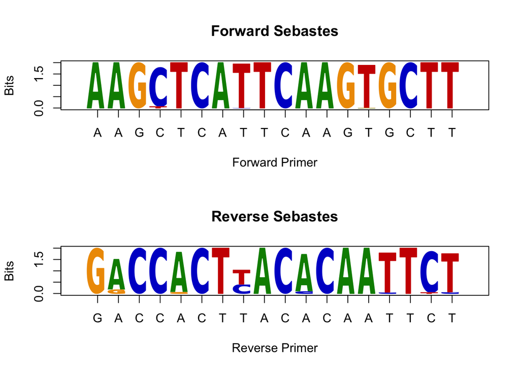

```r
  whitepaper(actualwidth,actualheight)
  if (is.null(primer))
    labels= TRUE
  else
    labels = strsplit(primer,"")[[1]]
  axis(1,at=1:ncol,labels=labels,cex.axis=cex.lab)
  axis(2)
  title(main=main,sub=sub,xlab=xlab,ylab=ylab,line=line,outer=outer)
  dnalogo(data,col=col,cex=cex)
}


Sebastes.forward = ecopcr.forward.shanon(ecopcr = fish,
                                     group = is_a_rockfish)
Sebastes.reverse = ecopcr.reverse.shanon(ecopcr = fish,
                                     group = is_a_rockfish)

Fish.forward = ecopcr.forward.shanon(ecopcr = fish,
                                     group = is_a_fish)
Fish.reverse = ecopcr.reverse.shanon(ecopcr = fish,
                                     group = is_a_fish)

par(mfrow=c(2,1))
dnalogoplot_2(Sebastes.forward$'TRUE',
            primer = "AAGCTCATTCAAGTGCTT",
            main='Forward Sebastes',xlab = "Forward Primer", ylab = "Bits")
dnalogoplot_2(Sebastes.reverse$'TRUE',
            primer = "GACCACTTACACAATTCT",
            main='Reverse Sebastes', xlab = "Reverse Primer", ylab = "Bits")
```

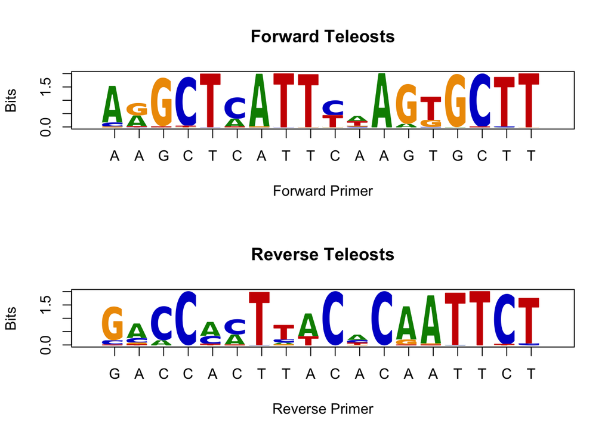

```r
dnalogoplot_2(Fish.forward$'TRUE',
            primer = "AAGCTCATTCAAGTGCTT",
            main='Forward Teleosts', xlab = "Forward Primer", ylab = "Bits")
dnalogoplot_2(Fish.reverse$'TRUE',
            primer = "GACCACTTACACAATTCT",
            main='Reverse Teleosts', xlab = "Reverse Primer", ylab = "Bits")
```

These plots show the match between the primer and the target sequence for Sebastes and all fish (Teleosts). This illustrates that the primer conservation is much better for Sebastes than for all Teleosts, showing that Sebastes sequences will be preferentially amplified.

### 148 Sebastes sequences amplified - 100 unique species

```r
sebastes.taxid = ecofind(taxo, '^Sebastes$')
is_a_rockfish=is.subcladeof(taxo,fish$taxid,sebastes.taxid)
table(is_a_rockfish)
```

```
## is_a_rockfish
## FALSE  TRUE
##  1791   148
```

```r
setwd("//Users/Markus/Documents/UCLA/Barber Lab/Honor's Thesis/ecoPCR_results")
primer369 = read.ecopcr.result("primer369_11.5.18.ecoPCR")
sebastes.pcr.369= subset(primer369,genus == 34820)
sebastes.species.369=unique(sebastes.pcr.369$species_name)
ss369df = as.data.frame(sebastes.species.369)
length(ss369df$sebastes.species.369)
```

```
## [1] 100
```

### Resolution for Sebastes

```r
only.sebastes=fish[is_a_rockfish,]
res = resolution(taxo,only.sebastes)
resolution = with(only.sebastes,
                  unique(data.frame(species_name,taxid,rank=res)))
t(t(sort(table(resolution$rank)/length(resolution$rank),decreasing = TRUE)))
```

```
##
##           [,1]
##   species 0.8461538
##   genus   0.1538462
```

### Resolution for Fish outside of Sebastes

```r
no.sebastes=fish[is_a_fish & !is_a_rockfish,]
res = resolution(taxo,no.sebastes)
resolution = with(no.sebastes,
                  unique(data.frame(species_name,taxid,rank=res))
)
t(t(sort(table(resolution$rank)/length(resolution$rank),decreasing = TRUE)))
```

```
##
##              [,1]
##   species    0.770676692
##   genus      0.146616541
##   subspecies 0.067669173
##   family     0.007518797
##   subfamily  0.007518797
```

### Mismatch Plot

##### Degree of mismatches influence taxonomical selection - far more mismatches for fish outside of sebastes

```r
group=rep('All Vertebrates',length(is_a_fish))
group[is_a_fish]='Teleosts'
group[is_a_rockfish]='Sebastes'
group=as.factor(group)
table(group)
```

```
## group
## All Vertebrates        Sebastes        Teleosts
##               1             148            1790
```

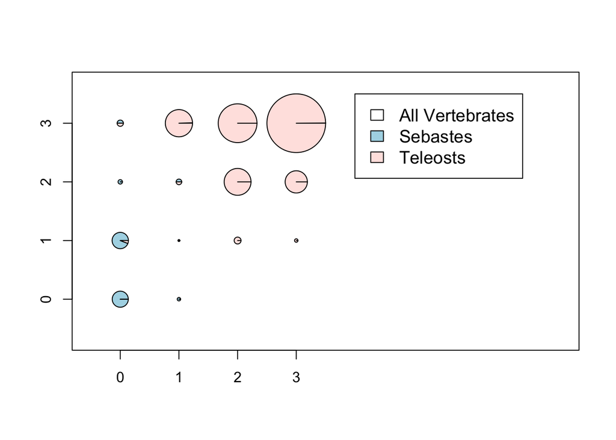

```r
par(mfcol=c(1,1))

mismatchplot_2 = function(ecopcr,group=NULL,
                        col=NULL,legend=NULL,
                        legend.cex=5,inset=c(0.02,0.02),
                        view.legend=TRUE,
                        maxerror=NA) {

  maxforward_error = max(ecopcr$forward_mismatch)
  maxreverse_error = max(ecopcr$reverse_mismatch)
  if (is.na(maxerror))
    maxerror=max(maxforward_error,maxreverse_error)

  if (is.null(group))
    group=factor(rep("all",dim(ecopcr)[1]))
  else
    group=as.factor(group)

  if (is.null(legend))
    legend = levels(group)

  actualheight= maxerror + 1
  actualwidth = maxerror + 5

  if (length(levels(group)) > 1 & view.legend)
    actualwidth = actualwidth

  whitepaper(actualwidth,actualheight,xmin=-0.5,ymin=-0.5,asp=1)

  axis(1,at=0:maxerror,
       labels=0:maxerror)

  axis(2,at=0:maxerror,
       labels=0:maxerror)


  data = aggregate(group,by=list(forward=factor(ecopcr$forward_mismatch,levels=0:maxerror),
                                 reverse=factor(ecopcr$reverse_mismatch,levels=0:maxerror)),
                   table)

  data <- data[rowSums(data[,c(-1,-2),drop=FALSE])>0, , drop=FALSE]

  if (is.null(col))
    col <- c("white", "lightblue", "mistyrose", "lightcyan",
             "lavender", "cornsilk")


  value=data[,c(-1,-2),drop=FALSE]
  x = as.integer(data[,1]) - 1
  y = as.integer(data[,2]) - 1
  diam = sqrt(rowSums(value))
  radius = diam / max(diam) / 2

  hide = mapply(pie.xy,x,y,
                data=lapply(1:(dim(value)[1]),function(y) value[y,]),
                radius=radius,
                label="",MoreArgs=list(col=col))


  if ((length(levels(group))) > 1 & view.legend)
    legend(4,3.5,legend=legend,fill=col, cex=1.2, inset=inset)

}


mismatchplot_2(fish,group = group)
```

The x-axis is the number of mismatches on the forward primer and the y-axis is the number of mismatches on the reverse primer. This demonstrates the same relationship as the previous plots which showed the conservation of the primers, where the primers are far more specific for Sebastes than they are for fish outside of Sebastes.